# PISA 2012 Project (Communicate Data Findings)

## by Jakub Revay

## Introduction

PISA - Programme for International Student Assessment- has gather an amazing and diverse data from 66 countries around the globe, including OECD and non OECD countries to preform possible studies, like this project were we dive indepth into the Socio-Economic,Parental School EdUcation and the Wealth stats and their effect on Grades.  
The full 2012 PISA dataset to download [PISA2012](https://s3.amazonaws.com/udacity-hosted-downloads/ud507/pisa2012.csv.zip). additionally,a Dictionary companion was downloaded which describes each column information inthe PISA dataset. The PISA data dictionary, which gives a brief explaination of each feature [PISADict](https://s3.amazonaws.com/udacity-hosted-downloads/ud507/pisadict2012.csv). the data given is collected in 2012 from students born in 1996-1997, and the main PISA study was to check:

- how well students have learned the school curriculum
- how well prepared they are for life beyond school.

thou we are going to study diffrent aspects, its good to know the main purpose of the original Project and its collected data.

## Gender stats & OECD Countries Percentile

#### looking at some fundemental stats, generally it seems there is not a noticable diffrence between genders, both are almost equal yet almost 60% of the data comes from OECD countries, will be intresting to see these 2 country groups effects

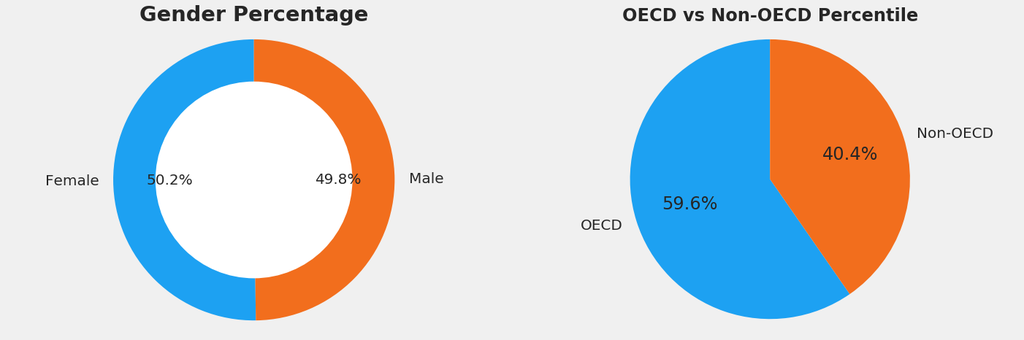

## Gender wealth gap per Grade

#### how the wealth index varies between genders per Grade ? it seems there is a general wealth gap between males and females which goes along for each grade. would wealth index have any effect on grade ?

```
Text(0,0.5,'Wealth')
```

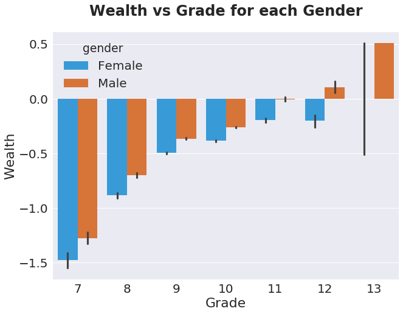

## Grade vs Wealth Regression

#### how much can wealth have and Impact on grades , looks there is a slight and almost neglectable positive regssion between the two, stating that wealth doesnt have a big impact on grades. most grades fall in 9 or 10 Grade

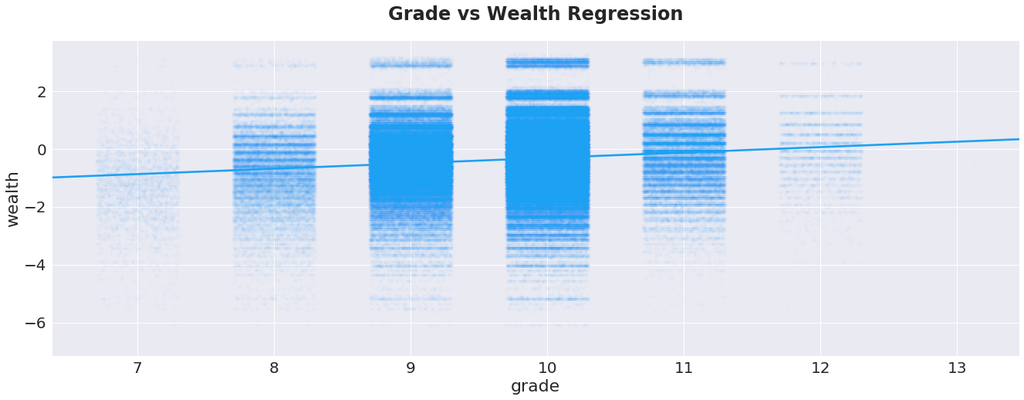

## Wealth vs Socio-Economic Regression

#### correlation between Wealth and Socio-Economic status , and as logically expected, there is a pretty strong positive correlation between the two, can it also mean that Socio-Economic staus have little if any impact on grades ?

```
Text(0.5,0,'Wealth Index')
```

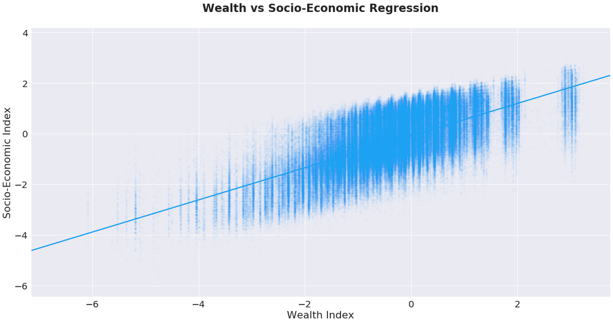

## Parents School Education vs Grade

#### parents Education level per grade - 3A-ready for theoretical university, 3B-ready for thechnical/occupation, the rest as stated

#### the higher the education level of the parents the better grades students have, 2 observation are intresting

#### - 3A educated mothers have higher count of good grade students!

#### - surpisingly secondary education parents slighly outpreform 3B educated parents wich are in a higher education class!

#### which let us conclude that best grades come from, 3A educated parents by far, followed by Secondary educated.**

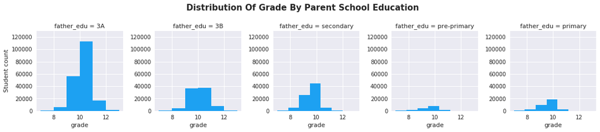

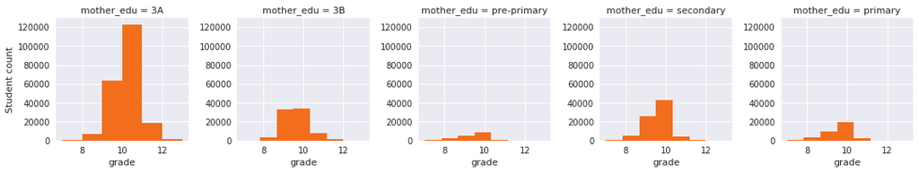

## Full Heatmap Demo

**lets go wild for a bit, making a demo dataframe ,turn all qualtitive into quantitive and find correllations using a 1 Heatmap.** **going all in on a ful heat map shows some intresting results, some we already expected, some not yet this plot make it clear how all the data is correlated.**

**to cuncoled here, we didint find any parameter that can suggest to have an clear impact on the Grade**

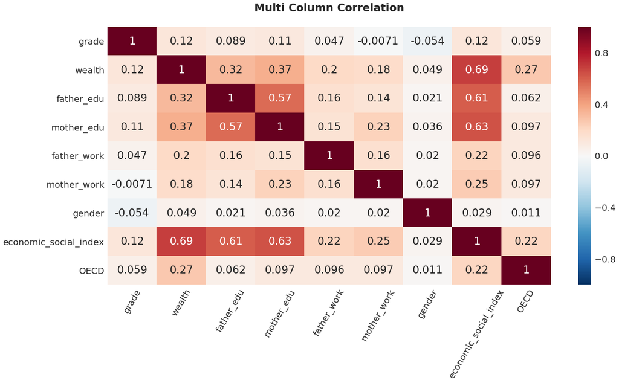

## Wealth vs Grade in OECD/ Non OECD Countries

**wealth varies alot in Non-OECD countries for each given grade,where OECD countries are a bit more condense. as we get higher in grades, countries have a slightly higher wealth index, thus very low correlated but still,excluding grade 12,where NonOECD countries have a lower wealth index for a significat high grade! this plots shows us that OECD countries are wealthier and have a higher chance to get high grades.**

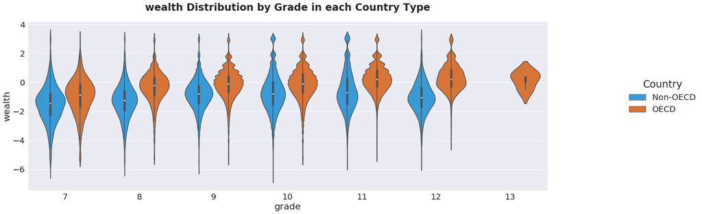